# WeRateDogs Twitter Data Analysis and Visualizations

### WeRateDogs is a twitter account that rates people's dogs with an amusing comment. These tweets also contain photos of the dogs. The twitter_archive_master dataset was cleaned and is used for the WeRateDog analysis. This data analysis will examine how the variables are related.

### The dictionary is shown below.

### DICTIONARY:

**twitter_archive_master.csv**

tweet_id : Tweet id  
in_reply_to_status_id : status id  
in_reply_to_user_id : user id  
timestamp : timestamp  
source : url source of tweet  
text : text from tweet  
retweeted_status_id : id from retweet  
retweeted_status_user_id : user id from retweet  
retweeted_status_timestamp : timestamp from retweet  
expanded_urls : url where tweet id is at the end  
rating_numerator : rate people's dogs, mostly larger than 10  
rating_denominator : almost always has a denominator of 10  
name : dog name  
doggo : big and older dog  
floofer : any dog, commonly has excess fur  
pupper : small doggo, usually younger than doggo  
puppo : teeange dog, between pupper and doggo  
jpg_url : the url of the jpg file  
img_num : image number that corresponded to the most confident prediction (up to four)  
p1 : the algorithm's #1 prediction for the image in the tweet  
p1_conf : how confident the algorithm is in its #1 prediction  
p1_dog : whether or not the #1 prediction is a breed of dog  
p2 : the algorithm's #2 prediction for the image in the tweet  
p2_conf : how confident the algorithm is in its #2 prediction  
p2_dog : whether or not the #2 prediction is a breed of dog  
p3 : the algorithm's #3 prediction for the image in the tweet  
p3_conf : how confident the algorithm is in its #3 prediction  
p3_dog : whether or not the #3 prediction is a breed of dog  
retweet_count : number of times tweet was retweeted  
favorite_count : number of times tweet was labeled favorite

# ANALYSIS

### Analysis for the Twitter_archive_master Dataset

- **Is there a relationship between retweet_count and favorite_count?**
- **How does the confidence of the three algorithm predictions compare to one another?**
- **How does the sum of all retweets for a given day vary over time?**

### Visualization

- **How do the dog stages('doggo', 'floofer', 'pupper', 'puppo') relate to rating_numerator?**

**How does the favorite count correlate with retweet count for each dog tweet?**

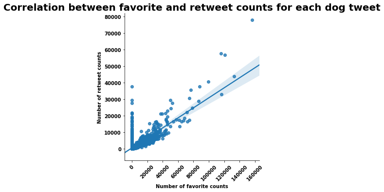

```python
Favorite_And_Retweet_Counts_Plot()
```

```python
Retweet_Favorite_Correlation()
```

```
0.7838886834353888
```

**Conclusion :The calculated correlation between retweet_count and favorite_count is 78% which implies a strong relationship between these two variables.**

**How does the confidence of the three algorithm predictions compare to one another?**

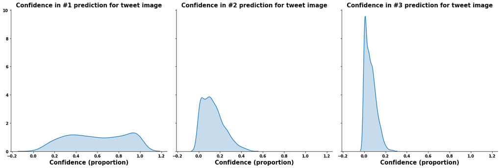

```python
Confidence_of_Algorithm_Predictions()
```

```python
Algorithm_Confidence_Mean()
```

| algorithm | conf |
| --- | --- |
| p1_alg | 0.594548 |
| p2_alg | 0.134589 |
| p3_alg | 0.060324 |

**Conclusion :For a particular tweet_id, the confidence of the algorithm's #1 prediction has an average that is higher than either #2 prediction or #3 prediction. The #3 prediction has the lowest confidence proportion.**

**How does the sum of all retweets for a given day vary over time?**

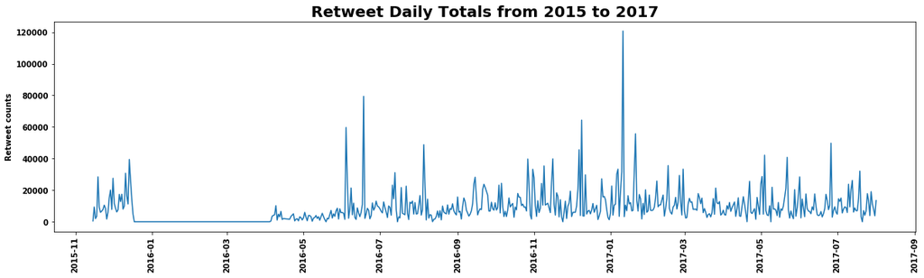

```python
Retweet_Daily_Totals_By_Month()
```

### Visualization

**How do the dog stages ('doggo', 'floofer', 'pupper', 'puppo', and multiple dog stages) relate to rating_numerator for a given tweet_id.**

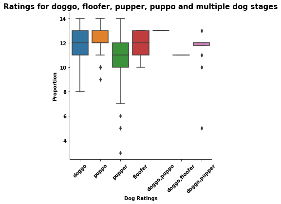

```python
Rating_For_Dog_Stage()
```

```python
Dog_Stage_Rating_Mean()
```

```
dog_stage
doggo            11.879518
doggo,floofer    11.000000
doggo,pupper     11.250000
doggo,puppo      13.000000
floofer          11.888889
pupper           10.788857
puppo            12.103448
Name: rating_numerator, dtype: float64
```